# Final_SQL

Hello Erik!

My name is Olga. I'm happy to review your project today.

When I will see mistake at the first time, I will just point it out. I let you find it and fix it by yourself. I'm trying to prepare you to work as an Data Analyst. SO, at a real job, your team lead will do the same. But if you can't handle this task yet, I will give you a more accurate hint at the next iteration.

You will find my comments below - **please do not move, modify or delete them**.

You can find my comments in green, yellow or red boxes like this:

**Reviewer's comment** Success. Everything is done succesfully.

**Reviewer's comment** Remarks. Some recommendations.

**Reviewer's comment** Needs fixing. The block requires some corrections. Work can't be accepted with the red comments.

You can answer me by using this:

**Student answer.**

**Overallv reviewer's comment** Erik, thank you for sending your project. You've done a really good job on it! All queries are correct. I'm glad to say that your project has been accepted. Keep up the good work, and good luck with the last project!

## Introduction/Goals

We have been given a database of one of the services competing in the market of book apps . It contains data on books, publishers, authors, and customer ratings and reviews of books. This information will be used to generate a value proposition for a new product. Several tasks will be done to determine useful metrics.

ERD Model:

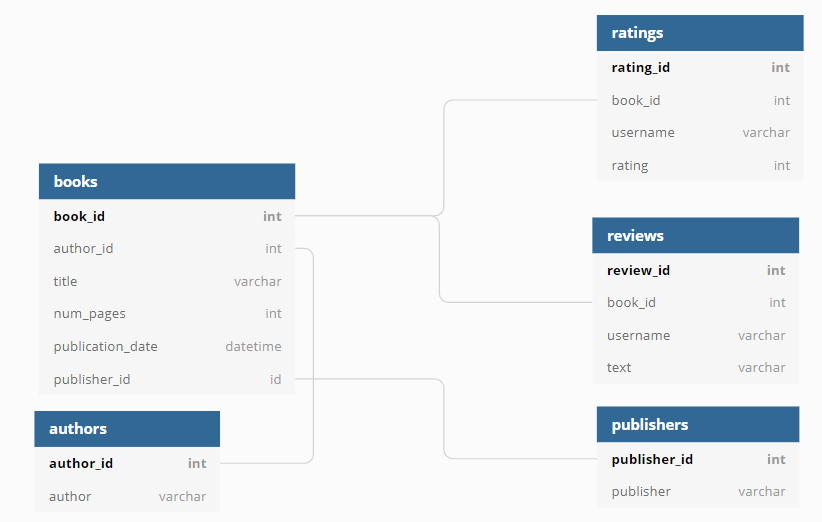

```python
# import libraries
import pandas as pd
from sqlalchemy import create_engine

db_config = {'user': 'practicum_student',         # username
             'pwd': 's65BlTKV3faNIGhmvJVzOqhs', # password
             'host': 'rc1b-wcoijxj3yxfsf3fs.mdb.yandexcloud.net',
             'port': 6432,              # connection port
             'db': 'data-analyst-final-project-db'}          # the name of the database

connection_string = 'postgresql://{}:{}@{}:{}/{}'.format(db_config['user'],
                                                                     db_config['pwd'],
                                                                       db_config['host'],
                                                                       db_config['port'],
                                                                       db_config['db'])

engine = create_engine(connection_string, connect_args={'sslmode':'require'})
```

**Reviewer's comment** Great, we have an introduction,scheme of our database and connection!

## Study Tables

```python
query = '''
SELECT *
FROM books
LIMIT 5;'''
pd.io.sql.read_sql(query, con = engine)
```

|  | book_id | author_id | title | num_pages | publication_date | publisher_id |
| --- | --- | --- | --- | --- | --- | --- |
| 0 | 1 | 546 | 'Salem's Lot | 594 | 2005-11-01 | 93 |
| 1 | 2 | 465 | 1 000 Places to See Before You Die | 992 | 2003-05-22 | 336 |
| 2 | 3 | 407 | 13 Little Blue Envelopes (Little Blue Envelope... | 322 | 2010-12-21 | 135 |
| 3 | 4 | 82 | 1491: New Revelations of the Americas Before C... | 541 | 2006-10-10 | 309 |
| 4 | 5 | 125 | 1776 | 386 | 2006-07-04 | 268 |

```python
query = '''
SELECT *
FROM ratings
LIMIT 5;'''
pd.io.sql.read_sql(query, con = engine)
```

|  | rating_id | book_id | username | rating |
| --- | --- | --- | --- | --- |
| 0 | 1 | 1 | ryanfranco | 4 |
| 1 | 2 | 1 | grantpatricia | 2 |
| 2 | 3 | 1 | brandtandrea | 5 |
| 3 | 4 | 2 | lorichen | 3 |
| 4 | 5 | 2 | mariokeller | 2 |

```python
query = '''
SELECT *
FROM reviews
LIMIT 5;'''
pd.io.sql.read_sql(query, con = engine)
```

|  | review_id | book_id | username | text |
| --- | --- | --- | --- | --- |
| 0 | 1 | 1 | brandtandrea | Mention society tell send professor analysis. ... |
| 1 | 2 | 1 | ryanfranco | Foot glass pretty audience hit themselves. Amo... |
| 2 | 3 | 2 | lorichen | Listen treat keep worry. Miss husband tax but ... |
| 3 | 4 | 3 | johnsonamanda | Finally month interesting blue could nature cu... |
| 4 | 5 | 3 | scotttamara | Nation purpose heavy give wait song will. List... |

```python
query = '''
SELECT *
FROM publishers
LIMIT 5;'''
pd.io.sql.read_sql(query, con = engine)
```

|  | publisher_id | publisher |
| --- | --- | --- |
| 0 | 1 | Ace |
| 1 | 2 | Ace Book |
| 2 | 3 | Ace Books |
| 3 | 4 | Ace Hardcover |
| 4 | 5 | Addison Wesley Publishing Company |

```python
query = '''
SELECT *
FROM authors
LIMIT 5;'''
pd.io.sql.read_sql(query, con = engine)
```

|  | author_id | author |
| --- | --- | --- |
| 0 | 1 | A.S. Byatt |
| 1 | 2 | Aesop/Laura Harris/Laura Gibbs |
| 2 | 3 | Agatha Christie |
| 3 | 4 | Alan Brennert |
| 4 | 5 | Alan Moore/David Lloyd |

The 'books' table is the main table, and its primary key 'book_id' is connected to the 'ratings', 'reviews' tables. The 'publishers' tables is connected via 'publisher_id', and the 'authors' table is connected via 'author_id'.

**Reviewer's comment** Yep, we can see our tables!

**Reviewer's comment** Also we should check duplicates and missing values.

## Tasks

### Find the number of books released after January 1, 2000

```python
query = '''
SELECT
    DISTINCT(COUNT(title)) AS books_count
FROM books
WHERE
    publication_date > '2000-01-01';'''
pd.io.sql.read_sql(query, con = engine)
```

|  | books_count |
| --- | --- |
| 0 | 819 |

**Reviewer's comment** Correct!

### Find the number of user reviews and the average rating for each book

```python
# ordering by avg_rating
query = '''
SELECT
    books.book_id,
    books.title,
    COUNT(DISTINCT(review_id)) AS reviews_count,
    AVG(rating) AS avg_rating
FROM books
INNER JOIN reviews USING(book_id)
INNER JOIN ratings USING (book_id)
GROUP BY books.book_id
ORDER BY avg_rating DESC, reviews_count DESC, title;'''
pd.io.sql.read_sql(query, con = engine)
```

|  | book_id | title | reviews_count | avg_rating |
| --- | --- | --- | --- | --- |
| 0 | 17 | A Dirty Job (Grim Reaper #1) | 4 | 5.00 |
| 1 | 444 | Moneyball: The Art of Winning an Unfair Game | 3 | 5.00 |
| 2 | 553 | School's Out—Forever (Maximum Ride #2) | 3 | 5.00 |
| 3 | 20 | A Fistful of Charms (The Hollows #4) | 2 | 5.00 |
| 4 | 55 | A Woman of Substance (Emma Harte Saga #1) | 2 | 5.00 |
| ... | ... | ... | ... | ... |
| 989 | 915 | The World Is Flat: A Brief History of the Twen... | 3 | 2.25 |
| 990 | 202 | Drowning Ruth | 3 | 2.00 |
| 991 | 316 | His Excellency: George Washington | 2 | 2.00 |
| 992 | 371 | Junky | 2 | 2.00 |
| 993 | 303 | Harvesting the Heart | 2 | 1.50 |

994 rows × 4 columns

```python
# ordering by reveiws_count
query = '''
SELECT
    books.book_id,
    books.title,
    COUNT(DISTINCT(review_id)) AS reviews_count,
    AVG(rating) AS avg_rating
FROM books
INNER JOIN reviews USING(book_id)
INNER JOIN ratings USING (book_id)
GROUP BY books.book_id
ORDER BY reviews_count DESC, avg_rating DESC, title;'''
pd.io.sql.read_sql(query, con = engine)
```

|  | book_id | title | reviews_count | avg_rating |
| --- | --- | --- | --- | --- |
| 0 | 948 | Twilight (Twilight #1) | 7 | 3.662500 |
| 1 | 302 | Harry Potter and the Prisoner of Azkaban (Harr... | 6 | 4.414634 |
| 2 | 299 | Harry Potter and the Chamber of Secrets (Harry... | 6 | 4.287500 |
| 3 | 656 | The Book Thief | 6 | 4.264151 |
| 4 | 734 | The Glass Castle | 6 | 4.206897 |
| ... | ... | ... | ... | ... |
| 989 | 187 | Debt of Honor (Jack Ryan #7) | 1 | 3.000000 |
| 990 | 446 | Moo Baa La La La! | 1 | 3.000000 |
| 991 | 2 | 1 000 Places to See Before You Die | 1 | 2.500000 |
| 992 | 318 | History of Beauty | 1 | 2.500000 |
| 993 | 943 | Tsubasa: RESERVoir CHRoNiCLE Vol. 1 | 1 | 2.500000 |

994 rows × 4 columns

As shown in the tables above, we found the number of reviews as well as the average rating score for each book, consisting of 994 books. From the first table, it is shown that the book with the highest rating and most reviews is "A Dirty Job", with a 5.0 score and 4 reviews. From the second table, "Twilight" has the most reviews at 7 but an average rating of 3.66. It may be advantageous to consider the ratings to be more reliable for books that have more reviews.

**Reviewer's comment** Well done!

### Identify the publisher that has released the greatest number of books with more than 50 pages

```python
query = '''
SELECT
    books.publisher_id,
    publishers.publisher,
    COUNT(books.title) as books_count
FROM publishers
INNER JOIN books ON publishers.publisher_id = books.publisher_id
WHERE books.num_pages > 50
GROUP BY books.publisher_id, publishers.publisher
ORDER BY books_count DESC
LIMIT 1;'''
pd.io.sql.read_sql(query, con = engine)
```

|  | publisher_id | publisher | books_count |
| --- | --- | --- | --- |
| 0 | 212 | Penguin Books | 42 |

After joining the publishers table with the books table, we were able to count the amount of books per publisher where the number of pages exceeds 50. After doing so, the top result was Penguin Books at 42 books.

**Reviewer's comment** You are right!

### Identify the author with the highest average book rating: look only at books with at least 50 ratings

```python
query = '''
SELECT
    books.author_id,
    authors.author,
    books.title,
    AVG(ratings.rating) AS avg_rating,
    COUNT(ratings.rating_id) AS rating_count
FROM books
    INNER JOIN authors ON books.author_id = authors.author_id
    INNER JOIN ratings ON books.book_id = ratings.book_id
GROUP BY
    books.author_id,
    books.title,
    authors.author
HAVING COUNT(ratings.rating_id) >= 50
ORDER BY avg_rating DESC
LIMIT 1;'''
pd.io.sql.read_sql(query, con = engine)
```

|  | author_id | author | title | avg_rating | rating_count |
| --- | --- | --- | --- | --- | --- |
| 0 | 236 | J.K. Rowling/Mary GrandPré | Harry Potter and the Prisoner of Azkaban (Harr... | 4.414634 | 82 |

To do this, the ratings and authors table were joined with the main books table via the proper connecting keys. The fields of author_id, author, and title were selected, and the avgerage rating as well as the number of ratings for each book were calculated and displayed. Then, after filtering by books that have at least 50 ratings (by counting the number of 'rating_id's), the table was ordered by descending avg_rating and limited to the first result. The title came out to be J.K. Rowling/Mary GrandPre's "Harry Potter and the Prisoner of Azkaban", with an average rating of 4.41 and 82 ratings.

**Reviewer's comment** Yep, Harry Potter is a winner!

### Find the average number of text reviews among users who rated more than 50 books

```python
query = '''
SELECT
    AVG(COUNT(DISTINCT(reviews.review_id))) OVER () AS avg_num_reviews
FROM reviews
    INNER JOIN ratings ON reviews.username = ratings.username
GROUP BY ratings.username
HAVING COUNT(DISTINCT(ratings.rating_id)) > 50
LIMIT 1;'''
pd.io.sql.read_sql(query, con = engine)
```

|  | avg_num_reviews |
| --- | --- |
| 0 | 24.333333 |

First, we joined the username of each reviewer to the ratings table via 'username'. After grouping by usernames that have rated more than 50 books, the average amount of unique reviews per user throughout all users was calculated. It was was found that users who rated more than 50 books had, on average, 24.3 reviews.

**Reviewer's comment** Correct!

**Reviewer's comment** Thank you for the conclusion!